# Regression analysis_Homework Assignment 3

心理所碩二 R08227112 林子堯

2020/10/19

# 1. Consider the following two models where $E(\boldsymbol{\varepsilon}) = 0$ and $Var(\boldsymbol{\varepsilon}) = \sigma^2\boldsymbol{I}$:

- **Model A:** $\boldsymbol{y = X_1 \beta_1 + \varepsilon}$
- **Model B:** $\boldsymbol{y = X_1 \beta_1 + X_2 \beta_2+ \varepsilon}$

**Show that $R_A^2 \leq R_B^2$.**

By the definition, the $R^2$ is

$$\begin{align}
R^2 &= \frac{SSR}{SST} = 1 - \frac{SSE}{SST} \\
&= 1 - \frac{\sum_{i=1}^n(y_i - \hat{y}_i)^2}{\sum_{i=1}^n (y_i - \bar{y})^2} \\
&= 1 - \frac{\boldsymbol{\hat{\varepsilon}^{\top}\hat{\varepsilon}}}{\boldsymbol{yCy}}
\end{align}$$

where $\boldsymbol{C} = \boldsymbol{I} - \frac{1}{n}\boldsymbol{11^{\top}}$. Let $\boldsymbol{\hat{\beta}_{1A}} = \underset{\boldsymbol{\beta_1}}{\arg \min} \left \| \boldsymbol{y - x_1\beta_1} \right \|^2$ and $(\boldsymbol{\hat{\beta}_{1B}, \hat{\beta}_{2B})^{\top}} = \underset{\boldsymbol{\beta_1, \beta_2}}{\arg \min} \left \| \boldsymbol{y - (x_1\beta_1 - x_2\beta_2)} \right \|^2$. By the definition of least square estimation, one has

$$\begin{align}
\boldsymbol{\hat{\varepsilon}_B^{\top}\hat{\varepsilon}_B} &= \underset{\boldsymbol{(\beta_1, \beta_2)^{\top}}}{\min} \left \| \boldsymbol{y - (x_1\beta_1 + x_2\beta_2)}\right \|^2 \\
&\leq \left \| \boldsymbol{y - (x_1\beta_1 + \boldsymbol{x_2} 0)}\right \|^2
\end{align}$$

for any $\boldsymbol{\beta_1}$ in the last part of the inequation. Therefore one has

$$\begin{align}
\boldsymbol{\hat{\varepsilon}_B^{\top}\hat{\varepsilon}_B} &= \left \| \boldsymbol{y - (x_1\hat{\beta}_{1B} + \boldsymbol{x_2}\hat{\beta}_{2B})}\right \|^2 \\
&\leq \left \| \boldsymbol{y - (x_1\hat{\beta}_{1A})}\right \|^2 = \boldsymbol{\hat{\varepsilon}_A^{\top}\hat{\varepsilon}_A}
\end{align}$$
$$\Rightarrow R_A^2 = 1 - \frac{\boldsymbol{\hat{\varepsilon_A}^{\top}\hat{\varepsilon_A}}}{\boldsymbol{yCy}} \leq 1 - \frac{\boldsymbol{\hat{\varepsilon_B}^{\top}\hat{\varepsilon_B}}}{\boldsymbol{yCy}} = R_B^2$$

# 2. Suppose we need to compare the effects of two drugs each administered to $n$ subjects. The model for the effect of the first drug is

$$y_{i1} = \beta_0 + \beta_1x_{i1} + \varepsilon_{i1}$$
**while for the second drug it is**
$$y_{i2} = \beta_0 + \beta_2x_{i2} + \varepsilon_{i2}$$
**and in each case $i = 1, . . . , n$ and $\bar{x}_1 = \bar{x}_2 = 0$. Assume that all observations are independent and that for each $i$ both $\varepsilon_{1i}$ and $\varepsilon_{2i}$ are normally distributed with mean 0 and variance $\sigma^2$.**

## a. Obtain the least squares estimator for $\boldsymbol{\beta} = (\beta_0, \beta_1, \beta_2)^{\top}$ and its covariance matrix.

Since $\beta_0$’s in both models are equal, I convert them to a multiple linear regression model,

$$\boldsymbol{y = X\beta + \varepsilon}$$

where

$$\boldsymbol{y} = \begin{pmatrix} y_{11} \\ \vdots \\ y_{n1} \\ y_{12} \\ \vdots \\ y_{n2} \end{pmatrix}, \quad
\boldsymbol{X} = \begin{pmatrix} 1 & x_{11} & 0 \\ \vdots & \vdots & \vdots \\ 1 & x_{n1} & 0 \\ 1 & 0 & x_{12} \\ \vdots & \vdots & \vdots \\ 1 & 0 & x_{n2} \end{pmatrix}, \quad
\boldsymbol{\beta} = \begin{pmatrix} \beta_0 \\ \beta_1 \\ \beta_2 \end{pmatrix}, \text{ and }
\boldsymbol{\varepsilon} = \begin{pmatrix} \varepsilon_{11} \\ \vdots \\ \varepsilon_{n1} \\ \varepsilon_{12} \\ \vdots \\ \varepsilon_{n2} \end{pmatrix} \sim N_{2n}(\boldsymbol{0}, \sigma^2\boldsymbol{I})$$

The least squares estimator for $\boldsymbol{\beta}$ is

$$\boldsymbol{\hat{\beta} = (X^{\top}X)^{-1}X^{\top}y}$$

and the covariance matrix of $\hat{\boldsymbol{\beta}}$ is

$$\begin{align}
Cov(\boldsymbol{\hat{\beta}}) &= \boldsymbol{(X^{\top}X)^{-1}X^{\top}}Cov(\boldsymbol{y})\boldsymbol{((X^{\top}X)^{-1}X^{\top})^{\top}} \\
&= \sigma^2\boldsymbol{(X^{\top}X)^{-1}}
\end{align}$$

## b. Estimate $\sigma^2$.

The residual is $\boldsymbol{\hat{\varepsilon} = y - \hat{y} = y - X\hat{\beta} = (I-H)y}$ and the expectation of sum of square residual is

$$\begin{align}
E(\boldsymbol{\hat{\varepsilon}^{\top}\hat{\varepsilon}}) &= E(\boldsymbol{y^{\top}(I-H)y}) \\
&= E(\boldsymbol{y^{\top}})\boldsymbol{(I-H)}E(\boldsymbol{y}) + trace(\boldsymbol{(I-H)Var(y)}) \\
&= \boldsymbol{(X\beta)^{\top}(I-H)(X\beta)} + trace(\boldsymbol{(I-H)}\sigma^2\boldsymbol{I}) \\
&= (2n - 3) \sigma^2
\end{align}$$

so, we can let $\frac{\boldsymbol{\hat{\varepsilon}^{\top}\hat{\varepsilon}}}{2n-3}$ be an unbiased estimator of $\sigma^2$.

## c. Write the test statistic for testing $\beta_1 = \beta_2$ against the alternative that $\beta_1 \neq \beta_2$.

The hypothesis test can rewrite as

$$\boldsymbol{C\beta = d} \quad vs. \boldsymbol{C\beta \neq d}$$
where $\boldsymbol{C} = \begin{pmatrix} 0 & 1 & -1 \end{pmatrix}$ with $rank(\boldsymbol{C}) = 1$ and $\boldsymbol{d} = 0$

The full model is

$$\boldsymbol{y} = \beta_0 + \boldsymbol{x_1}\beta_1 + \boldsymbol{x_2}\beta_2 + \boldsymbol{\varepsilon}$$

Let the least square estimator of $\boldsymbol{beta}$ be denoted as $\boldsymbol{\hat{\beta}}$. Then we know $SSE = \boldsymbol{\hat{\varepsilon}^{\top}\hat{\varepsilon}} \sim \sigma^2\chi_{2n-3}^2$.

On the other side, the reduced model (under $H_0: \beta_1 = \beta_2$) is

$$\boldsymbol{y} = \beta_0 + (\boldsymbol{x_1 + x_2})\beta_1 + \boldsymbol{\varepsilon}$$

the least square estimate of $\boldsymbol{beta}$ is $\boldsymbol{\hat{\beta}_{H_0}} = \boldsymbol{\hat{\beta} - (X^{\top}X)^{-1}C^{\top}(C(X^{\top}X)^{-1}C^{\top})^{-1}(C\hat{\beta} -d)}$ and the residual is $\boldsymbol{\hat{\varepsilon}_{H_0} = y - \hat{y}_{H_0} = y - X\hat{\beta}_{H_0}}$

By some calculation, one can get

$$\begin{align}
\Delta SSE &= SSE - SSE_{H_0} = \boldsymbol{\hat{\varepsilon}^{\top}\hat{\varepsilon} - \hat{\varepsilon}_{H_0}^{\top}\hat{\varepsilon}_{H_0}} \\
&= \boldsymbol{(C\hat{\beta}-d)^{\top}(C(X^{\top}X)^{-1}C^{\top})^{-1}(C\hat{\beta}-d)}
\end{align}$$

and under $H_0: \boldsymbol{C\beta = d}$, $\Delta SSE \sim \sigma^2\chi_{r=1}^2$.

Furthermore, $SSE$ is independent of $\Delta SSE$, so we can use the test statistic

$$F = \frac{\Delta SSE / 1}{SSE / (2n - 3)} = \frac{\frac{\Delta SSE}{\sigma^2} / 1}{\frac{SSE}{\sigma^2} / (2n - 3)} \sim F_{1, 2n-3}$$

We could reject $H_0$ if the test statistic $F$ value is greater then the critical value $F_{1, 2n-3}(\alpha)$, where $\alpha$ is significance level. Otherwise, we would retain $H_0$.

# 3. Consider the two models $\boldsymbol{y_1 = X_1\beta_1 + \varepsilon_1}$ and $\boldsymbol{y_2 = X_2\beta_2 + \varepsilon_2}$ where the $\boldsymbol{X_i}$’s are $n_i × p$ matrices. Suppose that $\boldsymbol{\varepsilon_i} ∼ N(\boldsymbol{0}, \sigma_i^2\boldsymbol{I})$ where $i = 1, 2$ and that $\boldsymbol{\varepsilon_1}$ and $\boldsymbol{\varepsilon_2}$ are independent.

## a. Assuming that the $σ_i'$s are known, obtain a test for the hypothesis $\boldsymbol{\beta_1 = \beta_2}$·

From the least square estimation, we have

$$\boldsymbol{\hat{\beta}_1 = (X_1^{\top}X_1)^{-1}X_1^{\top}y_1} \quad \& \quad \boldsymbol{\hat{\beta}_2 = (X_2^{\top}X_2)^{-1}X_2^{\top}y_2}$$

and since $\boldsymbol{y_i} \sim N_p(X_i\beta_i, \sigma_i^2I)$ and $\boldsymbol{\beta_i}$ is a linear combination of $\boldsymbol{y_i}$ for $i = 1, 2$, so

$$\boldsymbol{\hat{\beta}_1} \sim N_p \left ( \boldsymbol{\beta_1}, \sigma_1^2\boldsymbol{(X_1^{\top}X_1)^{-1}} \right ) \quad \& \quad \boldsymbol{\hat{\beta}_2} \sim N_p \left (\boldsymbol{\beta_2}, \sigma_2^2\boldsymbol{(X_2^{\top}X_2)^{-1}} \right )$$

Otherwise, $\boldsymbol{y_1}$ are mutually independent with $\boldsymbol{y_2}$, therefore $Cov(\boldsymbol{Ay_1}, \boldsymbol{By_2}) = \boldsymbol{A}Cov(\boldsymbol{y_1}, \boldsymbol{y_2})\boldsymbol{B^{\top}} = \boldsymbol{0}$ for any matrices $\boldsymbol{A}$ and $\boldsymbol{B}$. We can get

$$\begin{align}
&\boldsymbol{\hat{\beta}_1 - \hat{\beta}_2} \sim N_p \left ( \boldsymbol{(\beta_1 - \beta_2)}, (\sigma_1^2\boldsymbol{(X_1^{\top}X_1)^{-1}} + \sigma_2^2\boldsymbol{(X_2^{\top}X_2)^{-1}}) \right ) \\
\Rightarrow \quad &\frac{\boldsymbol{(\hat{\beta}_1 - \hat{\beta}_2) - (\beta_1 - \beta_2)}}{\sqrt{\sigma_1^2\boldsymbol{(X_1^{\top}X_1)^{-1}} + \sigma_2^2\boldsymbol{(X_2^{\top}X_2)^{-1}}}} \sim N_p \left ( \boldsymbol{0}, \boldsymbol{I} \right ) \\
\Rightarrow \quad &\frac{[\boldsymbol{(\hat{\beta}_1 - \hat{\beta}_2) - (\beta_1 - \beta_2)}]^{\top}[\boldsymbol{(\hat{\beta}_1 - \hat{\beta}_2) - (\beta_1 - \beta_2)}]}{\sigma_1^2\boldsymbol{(X_1^{\top}X_1)^{-1}} + \sigma_2^2\boldsymbol{(X_2^{\top}X_2)^{-1}}} \sim \chi_{p}^2
\end{align}$$

When the the $σ_i'$s are known, the test statistic for $\boldsymbol{\beta_1 = \beta_2}$ is $[\boldsymbol{(\hat{\beta}_1 - \hat{\beta}_2)}]^{\top}[\sigma_1^2\boldsymbol{(X_1^{\top}X_1)^{-1}} + \sigma_2^2\boldsymbol{(X_2^{\top}X_2)^{-1}}]^{-1}[\boldsymbol{(\hat{\beta}_1 - \hat{\beta}_2)}]$, which is distributed at chi-square distribution with $df = p$. We could reject the null hypothesis $H_0: \boldsymbol{\beta_1 = \beta_2}$ if the the test statistic is greater then $\chi_{p}^2(\alpha)$, where $\alpha$ is significance level. Otherwise, we would retain $H_0$.

## b. Assume that $\sigma_1 = \sigma_2$ but they are unknown. Derive a test for the hypothesis $\beta_1 = \beta_2$.

Let $\sigma = \sigma_1 = \sigma_2$ are unknown, the pooled sample variance is

$$s_p^2 = \frac{(n_1 - 1)s_1^2 + (n_2 - 1)s_2^2}{n_1 + n_2 - 2} = \frac{\boldsymbol{\hat{\varepsilon}_1^{\top}\hat{\varepsilon}_1 + \hat{\varepsilon}_2^{\top}\hat{\varepsilon}_2}}{n_1 + n_2 - 2} = \frac{\boldsymbol{y_1^{\top}(I-H_1)y_1 + y_2^{\top}(I-H_2)y_2}}{n_1 + n_2 - 2}$$

since $\frac{\boldsymbol{y_i^{\top}(I-H_i)y_i}}{\sigma^2} \sim \chi_{n_i-p}^2$ for $i = 1, 2$ and $y_{i1}$’s are independent of $y_{i2}$’s, one has

$$\begin{align}
&\frac{\boldsymbol{y_1^{\top}(I-H_1)y_1 + y_2^{\top}(I-H_2)y_2}}{\sigma^2} \sim \chi_{n_1 + n_2 - 2p}^2 \\
\Rightarrow \quad &\frac{(n_1 + n_2 - 2)s_p^2}{\sigma^2} \sim \chi_{n_1 + n_2 - 2p}^2
\end{align}$$

Furthermore,
$$\begin{align}
&E(\frac{(n_1 + n_2 - 2)s_p^2}{\sigma^2}) = n_1 + n_2 - 2p \\
\Rightarrow \quad &E(s_p^2) = \frac{\sigma^2}{n_1 + n_2 - 2p}(n_1 + n_2 - 2p) = \sigma^2
\end{align}$$
so, the pooled sample variance is a unbiased estimator for $\sigma^2$.

Combine the result form part a., the random vector

$$\frac{\boldsymbol{(\hat{\beta}_1 - \hat{\beta}_2) - (\beta_1 - \beta_2)}}{s_p\sqrt{\boldsymbol{(X_1^{\top}X_1)^{-1}} + \boldsymbol{(X_2^{\top}X_2)^{-1}}}} =
\frac{\frac{\boldsymbol{(\hat{\beta}_1 - \hat{\beta}_2) - (\beta_1 - \beta_2)}}{\sqrt{\sigma^2\boldsymbol{(X_1^{\top}X_1)^{-1}} + \sigma^2\boldsymbol{(X_2^{\top}X_2)^{-1}}}}}{\sqrt{\frac{(n_1 + n_2 - 2p)s_p^2 / \sigma^2}{n_1 + n_2 - 2p}}} \sim t_{n_1 + n_2 - 2p}$$

where $t_{n_1 + n_2 - 2p}$ is a p-variate t distribution with $df = n_1 + n_2 - 2p$. Furthermore, we sum of square the random vector in the above equation and divide it by $p$, we get

$$\frac{[\boldsymbol{(\hat{\beta}_1 - \hat{\beta}_2) - (\beta_1 - \beta_2)}]^{\top}[\boldsymbol{(\hat{\beta}_1 - \hat{\beta}_2) - (\beta_1 - \beta_2)}]}{ps_p^2(\boldsymbol{(X_1^{\top}X_1)^{-1}} + \boldsymbol{(X_2^{\top}X_2)^{-1}})}
= \frac{\frac{[\boldsymbol{(\hat{\beta}_1 - \hat{\beta}_2) - (\beta_1 - \beta_2)}]^{\top}[\boldsymbol{(\hat{\beta}_1 - \hat{\beta}_2) - (\beta_1 - \beta_2)}]}{\sigma^2\boldsymbol{(X_1^{\top}X_1)^{-1}} + \sigma^2\boldsymbol{(X_2^{\top}X_2)^{-1}}} / p}{\frac{(n_1 + n_2 - 2p)s_p^2 / \sigma^2}{n_1 + n_2 - 2p}}
\sim F_{p, n_1+n_2-2p}$$

where the numerator is distributed at $\chi_{p}^2 / p$ and the denominator is distributed at $\chi_{n_1 + n_2 - 2p}$. When $\sigma_1 = \sigma_2$ is unknown, the test statistic for $\boldsymbol{\beta_1 = \beta_2}$ is $\frac{1}{pS_p^2}[\boldsymbol{(\hat{\beta}_1 - \hat{\beta}_2)}]^{\top}[\boldsymbol{(X_1^{\top}X_1)^{-1}} + \boldsymbol{(X_2^{\top}X_2)^{-1}})]^{-1}[\boldsymbol{(\hat{\beta}_1 - \hat{\beta}_2)}]$, which is distributed at $F$ distribution with $df_1 = p$ and $df_2 = n_1 + n_2 - 2p$. In conclusion, We could reject the null hypothesis $H_0: \boldsymbol{\beta_1 = \beta_2}$ if the the test statistic is greater then $F_{p, n_1 + n_2 -2p}(\alpha)$, where $\alpha$ is significance level. Otherwise, we would retain $H_0$.

# 4. Moore (1975) reported the results of an experiment to construct a model for total oxygen demand in dairy wastes as a function of five laboratory measurements (Data is attached in the mail). Data were collected on samples kept in suspension in water in a laboratory for 220 days. Although all observations reported here were taken on the same sample over time, assume that they are independent. The measured variables are:

- **$y$ log(oxygen demand, mg oxygen per minute)**
- **$x_1$ biological oxygen demand, mg/liter**
- **$x_2$ total Kjeldahl nitrogen, mg/liter**
- **$x_3$ total solids, mg/liter**
- **$x_4$ total volatile solids, a component of $x_3$, mg/liter**
- **$x_5$ chemical oxygen demand, mg/liter**

## a. Fit a multiple regression model using $y$ as the dependent variable and all $x_j$’s as the independent variables.

First of all, we should load the data to R

```r
data <- readxl::read_excel("E3.7.xlsx", col_names =TRUE)
knitr::kable(data)
```

| Day | x.1 | x.2 | x.3 | x.4 | x.5 | y |
| --- | --- | --- | --- | --- | --- | --- |
| 0 | 1125 | 232 | 7160 | 85.9 | 8905 | 1.5563 |
| 7 | 920 | 268 | 8804 | 86.5 | 7388 | 0.8976 |
| 15 | 835 | 271 | 8108 | 85.2 | 5348 | 0.7482 |
| 22 | 1000 | 237 | 6370 | 83.8 | 8056 | 0.7160 |
| 29 | 1150 | 192 | 6441 | 82.1 | 6960 | 0.3130 |
| 37 | 990 | 202 | 5154 | 79.2 | 5690 | 0.3617 |
| 44 | 840 | 184 | 5896 | 81.2 | 6932 | 0.1139 |
| 58 | 650 | 200 | 5336 | 80.6 | 5400 | 0.1139 |
| 65 | 640 | 180 | 5041 | 78.4 | 3177 | -0.2218 |
| 72 | 583 | 165 | 5012 | 79.3 | 4461 | -0.1549 |
| 80 | 570 | 151 | 4825 | 78.7 | 3901 | 0.0000 |
| 86 | 570 | 171 | 4391 | 78.0 | 5002 | 0.0000 |
| 93 | 510 | 243 | 4320 | 72.3 | 4665 | -0.0969 |
| 100 | 555 | 147 | 3709 | 74.9 | 4642 | -0.2218 |
| 107 | 460 | 286 | 3969 | 74.4 | 4840 | -0.3979 |
| 122 | 275 | 198 | 3558 | 72.5 | 4479 | -0.1549 |
| 129 | 510 | 196 | 4361 | 57.7 | 4200 | -0.2218 |
| 151 | 165 | 210 | 3301 | 71.8 | 3410 | -0.3979 |
| 171 | 244 | 327 | 2964 | 72.5 | 3360 | -0.5229 |
| 220 | 79 | 334 | 2777 | 71.9 | 2599 | -0.0458 |

Our model is

$$y_i = \beta_0 + \beta_1x_{i1} + \beta_2x_{i2} + \beta_3x_{i3} + \beta_4x_{i4} + \beta_5x_{i5} + \varepsilon_i$$

where $\varepsilon_i$’s are mutually independent with mean 0 and variance $\sigma^2$ for all i.

I use the `lm()` function to fit multiple regression model in R

```r
full_lm <- lm(y ~ 1 + x.1 + x.2 + x.3 + x.4 + x.5, data)
summary(full_lm)
```

```
Call:
lm(formula = y ~ 1 + x.1 + x.2 + x.3 + x.4 + x.5, data = data)

Residuals:
     Min       1Q   Median       3Q      Max
-0.39447 -0.11847  0.00053  0.08313  0.56232

Coefficients:
              Estimate Std. Error t value Pr(>|t|)
(Intercept) -2.156e+00  9.135e-01  -2.360   0.0333 *
x.1         -9.012e-06  5.184e-04  -0.017   0.9864
x.2          1.316e-03  1.263e-03   1.041   0.3153
x.3          1.278e-04  7.690e-05   1.662   0.1188
x.4          7.899e-03  1.400e-02   0.564   0.5815
x.5          1.417e-04  7.375e-05   1.921   0.0754 .
---
Signif. codes:  0 '***' 0.001 '**' 0.01 '*' 0.05 '.' 0.1 ' ' 1

Residual standard error: 0.2618 on 14 degrees of freedom
Multiple R-squared:  0.8107,    Adjusted R-squared:  0.743
F-statistic: 11.99 on 5 and 14 DF,  p-value: 0.0001184
```

then the fitted model is

$$\begin{align}
\hat{E}(y_i | x_{i1}, \dots, x_{i5}) = \hat{y}_i = &-2.16 - 9.01 \times 10^{-6} x_{i1} + 1.32 \times 10^{-3} x_{i2} \\ &+ 1.28 \times 10^{-4} x_{i3} + 7.90 \times 10^{-3} x_{i4} + 1.42 \times 10^{-4} x_{i5}
\end{align}$$

## b. Now fit a regression model with only the independent variables $x_3$ and $x_5$. How do the new parameters, the corresponding value of $R^2$ and the t-values compare with those obtained from the full model?

Our reduced model now is

$$y_i = \beta_0 + \beta_3x_{i3} + \beta_5x_{i5} + \varepsilon_i$$

```r
reduced_lm <- lm(y ~ 1 + x.3 + x.5, data)
summary(reduced_lm)
```

```
Call:
lm(formula = y ~ 1 + x.3 + x.5, data = data)

Residuals:
     Min       1Q   Median       3Q      Max
-0.37768 -0.09357 -0.04241  0.06230  0.59623

Coefficients:
              Estimate Std. Error t value Pr(>|t|)
(Intercept) -1.371e+00  1.963e-01  -6.988 2.19e-06 ***
x.3          1.492e-04  5.473e-05   2.726   0.0144 *
x.5          1.419e-04  5.302e-05   2.676   0.0160 *
---
Signif. codes:  0 '***' 0.001 '**' 0.01 '*' 0.05 '.' 0.1 ' ' 1

Residual standard error: 0.2519 on 17 degrees of freedom
Multiple R-squared:  0.7872,    Adjusted R-squared:  0.7621
F-statistic: 31.44 on 2 and 17 DF,  p-value: 1.942e-06
```

then the fitted model is

$$\hat{E}(y_i | x_{i3}, x_{i5}) = \hat{y}_i = -1.37 + 1.49 \times 10^{-4} x_{i3} + 1.42 \times 10^{-4} x_{i5}$$

The coefficient of determination in the reduced model ($R^2 = 0.79$) is smaller the the full model ($R^2 = 0.81$). The t-value of $\beta_0$ is smaller in the reduced model and the t-value of $\beta_3$ & $\beta_5$ is greater in the reduced model. However, there have smaller p-value in the reduced model than in the full model, so triple of them are significance in the t test (under the significance level $\alpha = 0.05$).

# 5. Consider the data given in 4. Suppose the model is

$$y_i = \beta_0 + \beta_1x_{i1} + \beta_2x_{i2} + \beta_3x_{i3} + \beta_4x_{i4} + \beta_5x_{i5} + \varepsilon_i$$
**where $i = 1, \dots, n$ and $\boldsymbol{\varepsilon} = (\varepsilon_1, \dots , \varepsilon_n)^{\top} \sim N(0, σ^2I_n)$.**

## a. Test the hypothesis $\beta_2 = \beta_4 = 0$ at the 5 per cent level of significance.

Our reduced model is

$$y_i = \beta_0 + \beta_1x_{i1} + \beta_3x_{i3} + \beta_5x_{i5} + \varepsilon_i$$

```r
reduced2_lm <- lm(y ~ 1 + x.1 + x.3 + x.5, data)
summary(reduced2_lm)
```

```
Call:
lm(formula = y ~ 1 + x.1 + x.3 + x.5, data = data)

Residuals:
     Min       1Q   Median       3Q      Max
-0.38529 -0.10424 -0.03769  0.03625  0.58651

Coefficients:
              Estimate Std. Error t value Pr(>|t|)
(Intercept) -1.438e+00  2.353e-01  -6.111  1.5e-05 ***
x.1         -2.416e-04  4.472e-04  -0.540   0.5965
x.3          1.683e-04  6.613e-05   2.544   0.0216 *
x.5          1.656e-04  6.975e-05   2.375   0.0304 *
---
Signif. codes:  0 '***' 0.001 '**' 0.01 '*' 0.05 '.' 0.1 ' ' 1

Residual standard error: 0.2573 on 16 degrees of freedom
Multiple R-squared:  0.791, Adjusted R-squared:  0.7518
F-statistic: 20.18 on 3 and 16 DF,  p-value: 1.097e-05
```

We can use the F test to test the hypothesis

```r
anova(reduced2_lm, full_lm)
```

```
Analysis of Variance Table

Model 1: y ~ 1 + x.1 + x.3 + x.5
Model 2: y ~ 1 + x.1 + x.2 + x.3 + x.4 + x.5
  Res.Df     RSS Df Sum of Sq      F Pr(>F)
1     16 1.05927
2     14 0.95953  2  0.099733 0.7276 0.5005
```

## b. Find a 95 per cent C.I. for $\beta_1$.

## c. Find a 95 per cent C.I. for $\beta_3 + 2\beta_5$.

I calculate both of $95\%$ C.I for $\beta_1$ and $\beta_3 + 2\beta_5$ at the same time. The R code is as follows

```r
library(multcomp)
contrast <-  rbind("β1" = c(0, 1, 0, 0, 0, 0),
                   "β3+2*β5" = c(0, 0, 0, 1, 0, 2))
full_glht <- glht(full_lm, linfct = contrast)
summary(full_glht)
```

```
     Simultaneous Tests for General Linear Hypotheses

Fit: lm(formula = y ~ 1 + x.1 + x.2 + x.3 + x.4 + x.5, data = data)

Linear Hypotheses:
               Estimate Std. Error t value Pr(>|t|)
β1 == 0      -9.012e-06  5.184e-04  -0.017    1.000
β3+2*β5 == 0  4.111e-04  1.642e-04   2.504    0.039 *
---
Signif. codes:  0 '***' 0.001 '**' 0.01 '*' 0.05 '.' 0.1 ' ' 1
(Adjusted p values reported -- single-step method)
```

```r
full_confint <- confint(full_glht,
                        level = 0.95,
                        calpha = univariate_calpha()) # specify univariate confidence intervals
full_confint
```

```
     Simultaneous Confidence Intervals

Fit: lm(formula = y ~ 1 + x.1 + x.2 + x.3 + x.4 + x.5, data = data)

Quantile = 2.1448
95% confidence level


Linear Hypotheses:
             Estimate   lwr        upr
β1 == 0      -9.012e-06 -1.121e-03  1.103e-03
β3+2*β5 == 0  4.111e-04  5.899e-05  7.632e-04
```

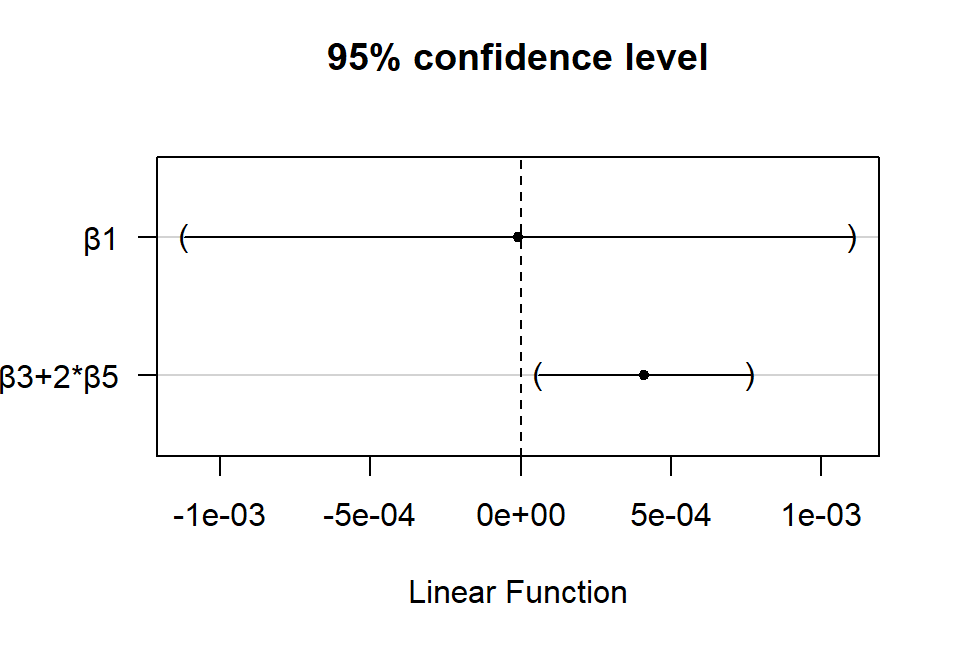

```r
plot(full_confint)
```

In part c., the estimate of $\beta_3 + 2\beta_5$ is $4.11 \times 10^{-4}$ and the $95\%$ C.I. is $[5.90 \times 10^{-5}, 7.63 \times 10^{-4}]$. On the contrary, this $95\%$ C.I does not contained 0, so we can reject the null hypothesis of $\beta_3 + 2\beta_5 = 0$.

*Note: In part b. and c., the significance level of per contrast is $0.05$. But we test both of tests simultaneously, actually, we should consider the family-wise significance level ($\alpha_{FW} = 0.05$) then refine the significance level of per contrast ($\alpha_{PC} < 0.05$) in each test.*